# Simulation Scenario B

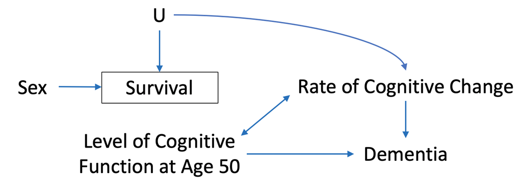

# Cohort Description

**You have a single incidence rate in your draft, but we have different incidence rates because we have a much longer study period (50 years instead of 10). Do we want this to be a table of incidence rates?**

Cumulative incidence of mortality during the study = 92.7%.

**I calculated this as the proportion of dead people over the study period… is this right?**

**WRONG– CHANGE ALL THIS** In this summary, we consider the scenario in which sex had no effect on development of dementia, but female sex decreased mortality risk

**Do we want a table for this as well since the HRs change so much over the 50 year period?**.

In our simulations, results that reject the null hypothesis that sex has no effect on dementia incidence (HR=1.00) are wrong.

# Matching European Survival Data

We used dementia incidence rate data from the EURODEM studies so we needed to switch from US to European survival data. We found cohort life tables on UC Berkeley’s repository: https://www.mortality.org/. Pulling data for the countries included in the EURODEM study, we plotted hazard ratios and decided that the Netherlands data provided a nice middle ground in the 50+ age group.

## Comparing Hazard Ratios

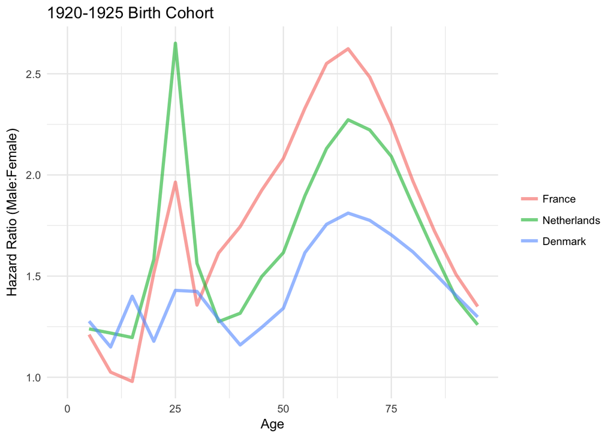

## Lambda values

We were able to solve for the $\lambda$ values in our survival model so that conditional probabilities of survival in our simulated data closely matched those calculated from the Netherlands life tables:

|  | Age 50-55 | 55-60 | 60-65 | 65-70 | 70-75 | 75-80 | 80-85 | 85-90 | 90-95 |
| --- | --- | --- | --- | --- | --- | --- | --- | --- | --- |
| Lambda | 0.00334 | 0.00486 | 0.00719 | 0.01116 | 0.01933 | 0.03444 | 0.06568 | 0.13646 | 0.32339 |

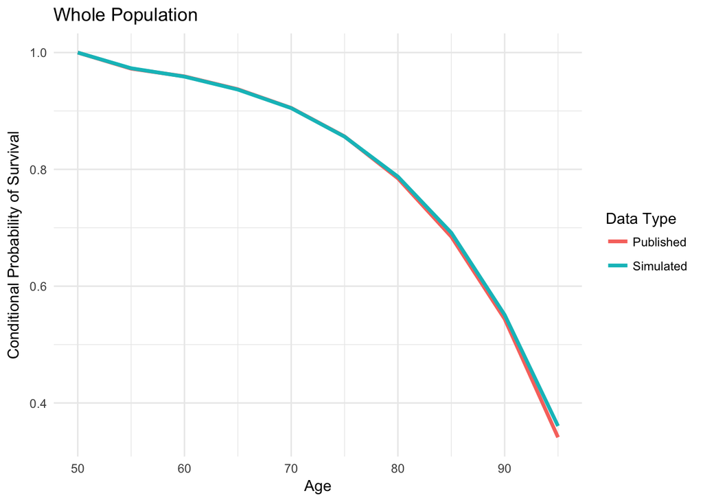

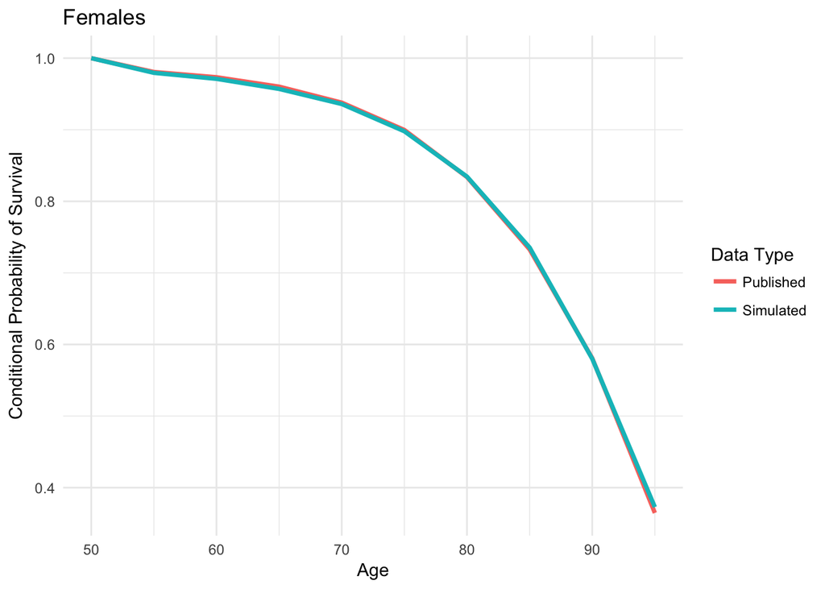

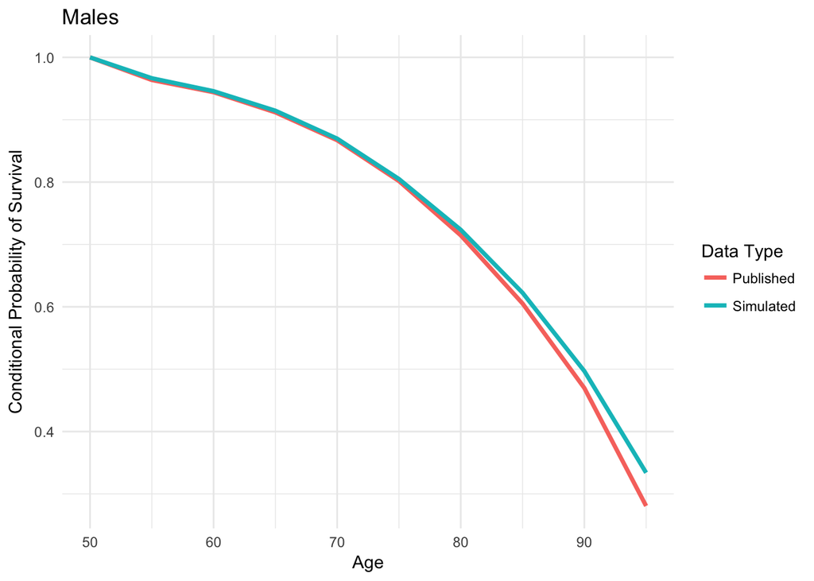

## Hazard Ratios

Ages on the x-axis represent the age at the start of interval, i.e. 50 represents the HR for the interval [50, 55).

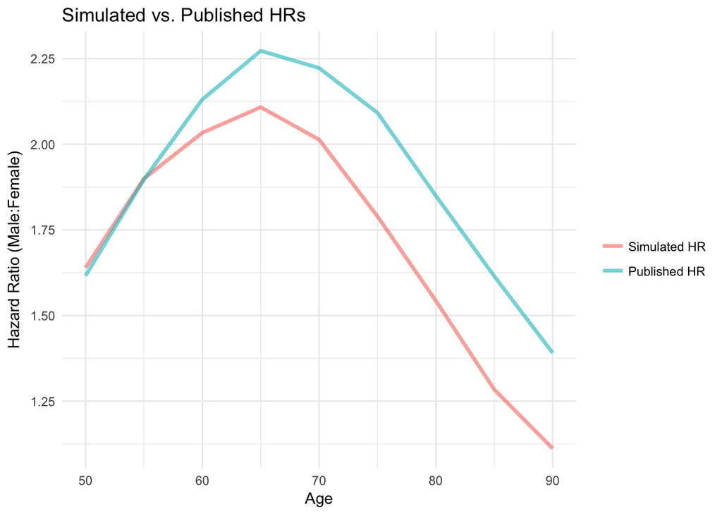

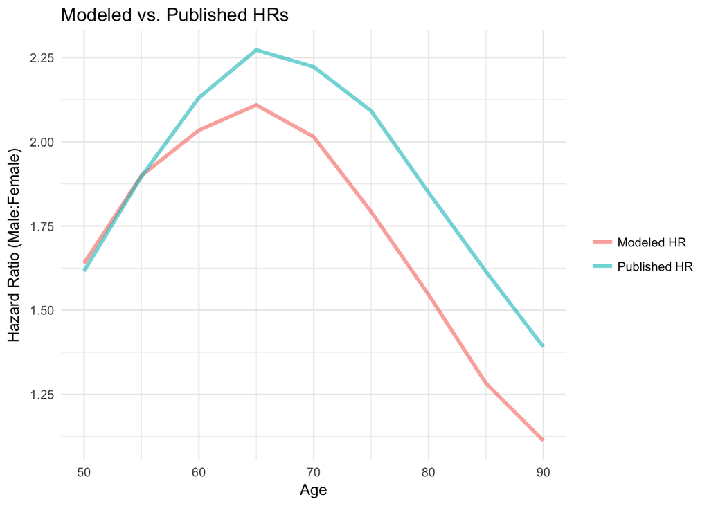

# Cognitive Trajectories

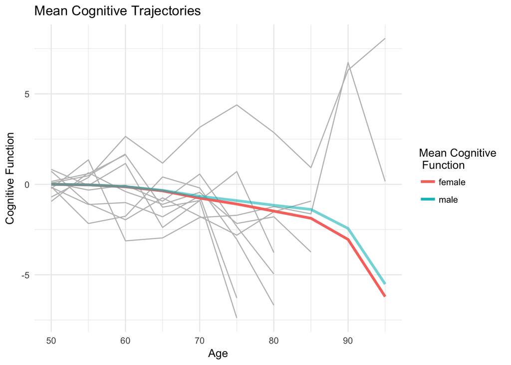

Mean slopes at each interval:

|  | Age 50-55 | 55-60 | 60-65 | 65-70 | 70-75 | 75-80 | 80-85 | 85-90 | 90-95 |
| --- | --- | --- | --- | --- | --- | --- | --- | --- | --- |
|  | -0.00607 | -0.02447 | -0.05217 | -0.09007 | -0.090071 | -0.117471 | -0.150071 | -0.352071 | -0.677071 |

Variance of random slope for each interval:

|  | Age 50-55 | 55-60 | 60-65 | 65-70 | 70-75 | 75-80 | 80-85 | 85-90 | 90-95 |
| --- | --- | --- | --- | --- | --- | --- | --- | --- | --- |
|  | 0.001332 | 0.001665 | 0.001998 | 0.00233 | 0.0035 | 0.005 | 0.011 | 0.015 | 0.015 |

# Matching Dementia Incidence Rates

Source: Gender differences in the incidence of AD and vascular dementia: The EURODEM Studies (Andersen 1999); Table 2

|  | Age 50-55 | 55-60 | 60-65 | 65-70 | 70-75 | 75-80 | 80-85 | 85-90 | 90-95 |
| --- | --- | --- | --- | --- | --- | --- | --- | --- | --- |
| Simulated | 0 | 1.056 | 2.618 | 2.783 | 5.293 | 11.915 | 23.983 | 36.67 | 53.591 |
| Published | NA | NA | NA | 3.149 | 7.071 | 16.697 | 31.952 | 48.954 | 69.433 |

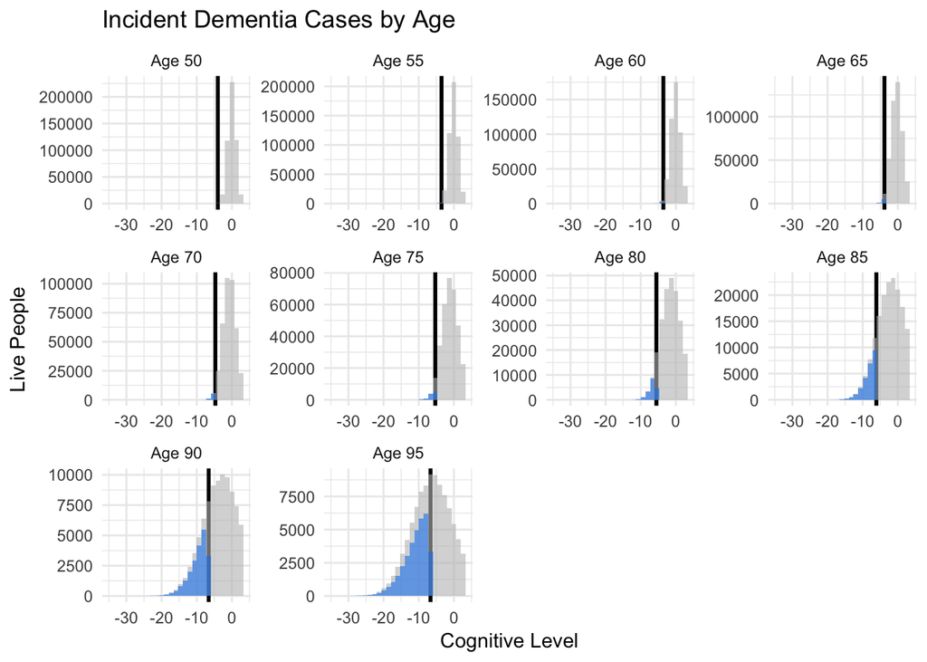

## Percentiles associated with each dementia cut point

The percentile is the proportion of susceptible that will be diagnosed with dementia

|  | Age 50 | Age 55 | Age 60 | Age 65 | Age 70 | Age 75 | Age 80 | Age 85 | Age 90 | Age 95 |
| --- | --- | --- | --- | --- | --- | --- | --- | --- | --- | --- |
| Dementia Cutoff | -4.000000 | -3.510000 | -3.560000 | -3.820000 | -4.700000 | -5.290000 | -5.550000 | -6.120000 | -6.600000 | -6.650000 |
| Percentile | 0.000132 | 0.001583 | 0.005481 | 0.013781 | 0.015964 | 0.031022 | 0.071041 | 0.146661 | 0.242694 | 0.455672 |

## Dementia HRs

|  | Age 50-55 | 55-60 | 60-65 | 65-70 | 70-75 | 75-80 | 80-85 | 85-90 | 90-95 |
| --- | --- | --- | --- | --- | --- | --- | --- | --- | --- |
|  | 1.2 | 1.16732 | 1.2538 | 1.4329 | 1.71332 | 2.04229 | 2.34293 | 2.55795 | 2.691 |

## Prevalance of dementia

Estimating this is not our primary goal, but we thought this might be another good sanity check. We expect that these numbers are higher than what they should be because in our model, dementia does not kill anyone.

|  | Age 50 | Age 55 | Age 60 | Age 65 | Age 70 | Age 75 | Age 80 | Age 85 | Age 90 | Age 95 |
| --- | --- | --- | --- | --- | --- | --- | --- | --- | --- | --- |
|  | 0.000118 | 0.001696 | 0.007052 | 0.020019 | 0.032736 | 0.055847 | 0.109316 | 0.213624 | 0.359481 | 0.552405 |

# Distribution of U

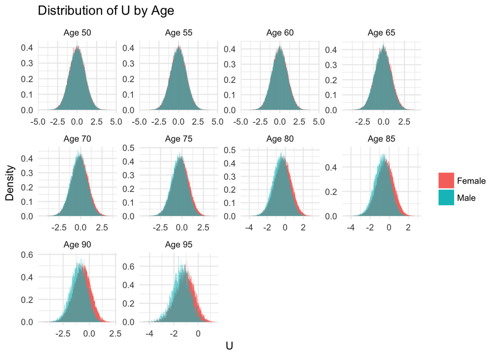